# Zadanie SKNDS

Model predykcyjny zmiennej Price

Wiktor Socha

2025-10-27

# Opis

- Celem analizy/projektu było przygotowanie, oczyszczenie przesłanych danych, stworzenie modelu predykcyjnego dla zmiennej Price, wizualizacja danych oraz zawarcie wniosków/rekomendacji.
- Przed rozpoczęciem pracy dotyczącej diamentów, zapoznałem się z podmiotem analizy. Wyszukałem w internecie informacje dotyczące klasycznych cen, wag, czy też wymiarów diamentów aby wiedzieć, jakie dane ewentualnie odrzucić z naszego modelu predykcji. Na wstępie włączyłem excel, zapoznałem się z danymi, przefiltrowałem wartości budzące wątpliwości oraz wykryłem braki w wierszach.
- Następnie w Rstudio podjąłem kroki takie jak: ustalenie nierealistycznych wartości zmiennych, odpowiednie sformatowanie kolumn oraz usunięcie wierszy z brakami danych. Ponadto, przefiltrowałem dane zmiennych, tak aby pokazywały wyłącznie realne wartości: ustaliłem wartość dla masy karatowej (Carat) w przedziale 0.1-15, dla zmiennej (Depth) 40%-80%, dla zmiennej (Table) 40%-95%, ustaliłem dodatnią cenę bez ekstremów oraz dodatnie wymiary o realistycznych wartościach. Dzięki czynnościom powyżej otrzymałem wiarygodną podstawę do zbudowania modelu.
- Celem analizy jest nie tylko predykcja ceny, ale również identyfikacja czynników wpływających na jej poziom oraz ocena siły tego wpływu. Z tego powodu jako model bazowy zastosowano **regresję liniową**, charakteryzującą się wysoką interpretacyjnością.

# Streszczenie

- Po oczyszczeniu danych, zbudowałem model regresji liniowej. Aby spełnić założenia metodologiczne, zmienne kluczowe (Price i Carat) zostały zlogarytmowane. Model wykazał się bardzo wysoką skutecznością, wyjaśniającą **98.2%** zmienności logarytmu ceny. Najważniejszymi czynnikami wpływającymi na cenę okazały się masa `log_carat`, czystość `clarity` i kolor `Color`. Zmienne opisujące proporcje diamentu (`Depth`, `Table`). okazały się statystycznie nieistotne.

# 1. Czyszczenie danych, wstępna analiza zmiennych

- Na początku ustaliłem nierealistyczne wartości zmiennej Carat za pomocą komendy:

`unrealistic_carats=c(0.0001, 0.0111, 21, 85, 86, 91, 100, 321, 1022, 2121, 21212, 34241)`

- W drugiej kolejności sformatowałem kolumny:

`mutate(cut = trimws(cut)) %>% oraz mutate(across(c(carat, depth, table, price, x, y, z), as.numeric)) %>%`

- Następnie usunąłem wiersze z brakami danych:

`filter(!is.na(carat) & !is.na(depth) & !is.na(table) & !is.na(price) & !is.na(x) & !is.na(y) & !is.na(z)) %>%`

- Oraz przefiltrowałem dane w taki sposób, aby pozostawały realne informacje, takie jak:

  **Realistyczna masa karatowa (między 0.1 a 15)**

  **Realistyczna wartość depth (40-80%)**

  **Realistyczna wartość table (40-95%)**

  **Realistyczna cena (dodatnia, bez ekstremow)**

  **Realistyczne wymiary (dodatnie, z górnym sensownym limitem)**
- Po sprawdzeniu ilości wierszy bazy danych przed i po czyszczeniu (cleaningu), spora część oryginalnych danych została usunięta z powodu braków lub błędów:

`Liczba wierszy przed czyszczeniem: 10050`

`Liczba wierszy po czyszczeniu: 7566`

- Po wpisaniu komendy `summary(diamenty_clean)`, możemy wysnuć wstępną analizę mówiącą nam, że

```
##      carat            cut               color             clarity
##  Min.   :0.2000   Length:7566        Length:7566        Length:7566
##  1st Qu.:0.4000   Class :character   Class :character   Class :character
##  Median :0.7000   Mode  :character   Mode  :character   Mode  :character
##  Mean   :0.8003
##  3rd Qu.:1.0400
##  Max.   :4.0100
##      depth           table           price             x
##  Min.   :43.00   Min.   :51.00   Min.   :  335   Min.   : 3.840
##  1st Qu.:61.10   1st Qu.:56.00   1st Qu.:  942   1st Qu.: 4.700
##  Median :61.90   Median :57.00   Median : 2402   Median : 5.690
##  Mean   :61.78   Mean   :57.44   Mean   : 3925   Mean   : 5.733
##  3rd Qu.:62.60   3rd Qu.:59.00   3rd Qu.: 5282   3rd Qu.: 6.530
##  Max.   :79.00   Max.   :73.00   Max.   :18823   Max.   :10.140
##        y                z
##  Min.   : 3.800   Min.   :1.410
##  1st Qu.: 4.710   1st Qu.:2.910
##  Median : 5.710   Median :3.520
##  Mean   : 5.735   Mean   :3.542
##  3rd Qu.: 6.530   3rd Qu.:4.030
##  Max.   :10.100   Max.   :6.310
```

**Carat(Masa)**

- Większość diamentów w tym zbiorze jest stosunkowo mała (Mediana wynosi 0.7 karata, a średnia 0.8 karata)
- Ponadto, wyższa średnia od mediany wskazuje nam, że rozkład wykazuje prawostronną skośność - jest więcej mniejszych diamentów, ale obecność kilku większych “ciągnie” średnią w górę

**Depth(Głębokość%)**

- Wartości zmiennej ‘Depth’ koncentrują się wokół średniej 61.78% i mediany 61.90%
- Oznacza to, że rozkład jest stosunkowo symetryczny

**Table(Tabela)**

- Podobnie jak zmienna ‘Depth’, wartości skupiają się wokół średniej 57.44% i mediany 57.00%
- Rozkład jest lekko prawostronnie skośny

**Price(Cena)**

- Ceny są mocno prawostronnie skośne. Mediana wynosi 2402$, podczas gdy średnia to 3925$. Oznacza to, że większość diamentów jest tańsza, ale istnieje grupa znacznie droższych kamieni, które zawyżają średnią.
- Najtańszy diament kosztuje 335$, a najdroższy 18823$. Połowa diamentów ma cenę w przedziale od 942$ do 5282$.

**x,y,z(Wymiary)**

# 2. Budowa modelu

## 2a. Wybór oraz przekształcenie zmiennych

- Do zbudowania modelu predykcyjnego zmiennej objaśnianej ‘Price’, użyłem zmiennych objaśniających ‘Carat’, ‘Cut’, ‘Color’, ‘Clarity’, ‘Depth’, ‘Table’.

**Wybierając zmienne objaśniające, pominąłem zmienne z wymiarami ‘(z, y, z)’, ponieważ założyłem, że są one bardzo silnie skorelowane ze zmienną ‘Carat’. Dzięki temu uniknąłem problemu współliniowości.**

- Oraz sprawdziłem typy zmiennych kategorycznych a następnie przekształciłem zmienne na faktory z odpowiednim podziałem na klasy (od najgorszej do najlepszej jakości diamentów).

**Wizualizacja rozkładu gęstości dla zmiennej ‘Price’**

Analizując grafikę, rozkład zmiennej price jest mocno prawostronnie skośny. Gdy zmienna zależna (price) jest tak skośna, istnieje ryzyko, że model nie będzie spełniać potrzebnych założeń.

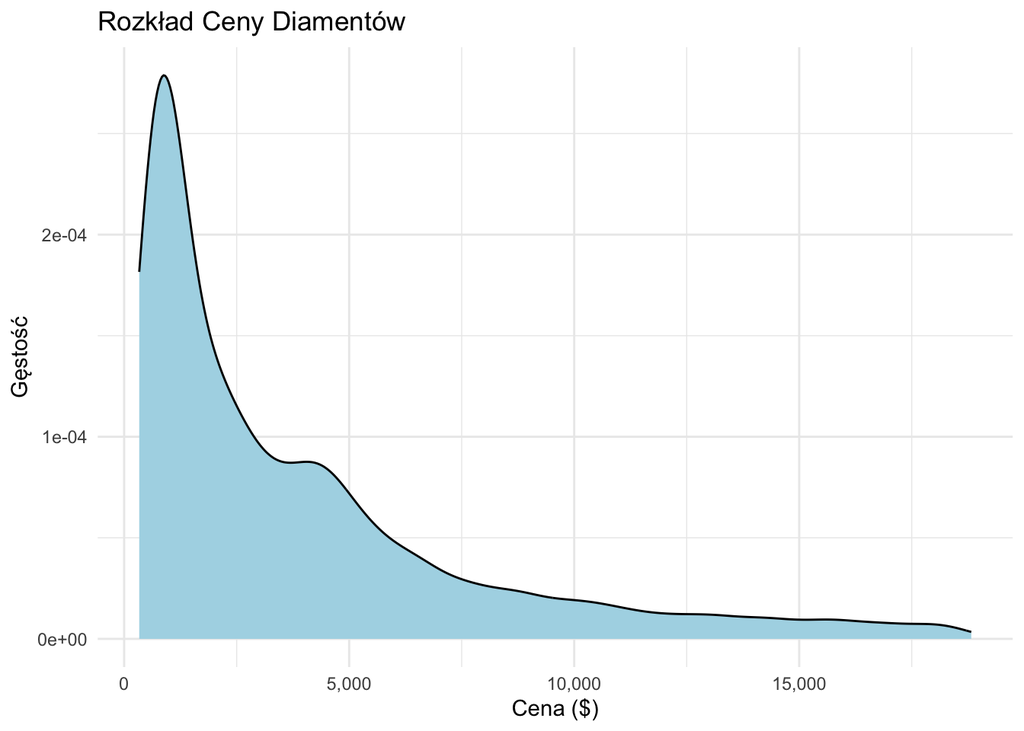

```r
p1
```

- W związku z tym, podjąłem decyzje o zlogarytmowaniu zmiennych price i carat:

`diamenty_model_data = diamenty_clean %>% mutate(log_price = log(price), log_carat = log(carat))`

## 2b. Podzielenie danych na zbiory oraz ustalenie ziarna losowości

- Podzieliłem dane na zbiór treningowy (75%) i testowy (25%)

`split = sample.split(diamenty_model_data$log_price, SplitRatio = 0.75)`

`train_data = subset(diamenty_model_data, split == TRUE)`

`test_data = subset(diamenty_model_data, split == FALSE)`

`diamenty_model_data = diamenty_clean %>% mutate(log_price = log(price), log_carat = log(carat))`

# 3. Model predykcji

- Zbudowałem model regresji liniowej logarytmu ze zmiennej ‘Price’ (log_Price) na podstawie log_Carat i pozostałych zmiennych (‘Carat’, ‘Cut’, ‘Color’, ‘Clarity’, ‘Depth’, ‘Table’)

`model = lm(log_price ~ log_carat + cut + color + clarity + depth + table, data = train_data)`

- Oraz dokonałem analizy informacji dotyczących modelu (współczynniki, istotność, R-kwadrat)

`summary(model)`

```
##
## Call:
## lm(formula = log_price ~ log_carat + cut + color + clarity +
##     depth + table, data = train_data)
##
## Residuals:
##      Min       1Q   Median       3Q      Max
## -0.76242 -0.08641  0.00003  0.08455  1.33955
##
## Coefficients:
##               Estimate Std. Error t value Pr(>|t|)
## (Intercept)   7.673738   0.132941  57.723  < 2e-16 ***
## log_carat     1.873444   0.003540 529.238  < 2e-16 ***
## cutGood       0.080299   0.011840   6.782 1.31e-11 ***
## cutIdeal      0.163597   0.011878  13.773  < 2e-16 ***
## cutPremium    0.145772   0.011366  12.826  < 2e-16 ***
## cutVery Good  0.121822   0.011387  10.698  < 2e-16 ***
## colorE       -0.044543   0.006603  -6.746 1.67e-11 ***
## colorF       -0.088037   0.006647 -13.244  < 2e-16 ***
## colorG       -0.149305   0.006540 -22.830  < 2e-16 ***
## colorH       -0.233454   0.006992 -33.390  < 2e-16 ***
## colorI       -0.361166   0.007625 -47.365  < 2e-16 ***
## colorJ       -0.499310   0.009498 -52.570  < 2e-16 ***
## clarityIF     1.101460   0.017719  62.163  < 2e-16 ***
## claritySI1    0.585067   0.014749  39.668  < 2e-16 ***
## claritySI2    0.421994   0.014814  28.485  < 2e-16 ***
## clarityVS1    0.811680   0.015105  53.737  < 2e-16 ***
## clarityVS2    0.738169   0.014843  49.731  < 2e-16 ***
## clarityVVS1   1.011508   0.016266  62.185  < 2e-16 ***
## clarityVVS2   0.938141   0.015656  59.922  < 2e-16 ***
## depth         0.001376   0.001451   0.948    0.343
## table         0.001496   0.001050   1.424    0.154
## ---
## Signif. codes:  0 '***' 0.001 '**' 0.01 '*' 0.05 '.' 0.1 ' ' 1
##
## Residual standard error: 0.1345 on 5653 degrees of freedom
## Multiple R-squared:  0.9824, Adjusted R-squared:  0.9823
## F-statistic: 1.574e+04 on 20 and 5653 DF,  p-value: < 2.2e-16
```

- Na podstawie tego modelu regresji liniowej możemy stwierdzić, że:

**log_carat (Masa):**

Logarytm masy ma **najsilniejszy** wpły na logarytm ceny (zależność log vs log). Oznacza to, że wzrost masy diamentu o **1%** jest związany ze wzrostem jego ceny średnio **o ok. 1.87%** ceteris paribus

**depth (Głębokość) i table:**

**cut (Szlif):**

Bazując na powyższej informacji, cena diamentu rośnie, im “lepszy” szlif:

**color (Kolor):**

**clarity (Czystość):**

**R-kwadrat wynosi: 0.9824 a skorygowany R-kwadrat wynosi: 0.9823.**

- Oznacza to, że model ten (uwzględniający logarytm karatów, szlif, kolor, czystość, głębokość i taflę) jest w stanie wyjaśnić aż 98,24% zmienności w logarytmie ceny diamentów. Wskazuje on na bardzo silne dopasowanie modelu do danych.

**Skorygowany R-kwadrat jest bardzo bliski wartości 1, co potwierdza, że model nie jest “przeładowany” zbędnymi zmiennymi**

## 3a. Sprawdzenie jakości modelu

- Aby sprawdzić jakość modelu dokonałem predykcji na zbiorze testowym:

`predictions_log = predict(model, newdata = test_data)`

- Wyliczyłem RMSE dla logarytmu ceny (średnia oczekiwana różnica miedzy wartością przewidywaną a rzeczywistą)

`rmse_log=sqrt(mean((test_data$log_price - predictions_log)^2))`

`cat("RMSE (dla log_price):", rmse_log, "\n")`

```
## RMSE (dla log_price): 0.1343203
```

- Wartość RMSE (dla log_price): 0.1343203 oznacza, że standardowe odchylenie błędów prognozy modelu wynosi 0.1343. Jesto to miara tego, jak bardzo “przeciętnie” przewidywania modelu dotyczące logarytmu ceny różnią się od rzeczywistego logarytmu ceny. RMSE na poziomie 0.1343 dla log_price to bardzo dobry wynik przy R-kwadrat wynoszący 98%. Oznacza on, że model jest nie tylko dobrze dopasowany, ale jego błędy predykcji są relatywnie małe (13-14%).
- Oraz obliczyłem R-kwadrat dla zbioru testowego

`sse = sum((test_data$log_price - predictions_log)^2)`

`sst = sum((test_data$log_price - mean(test_data$log_price))^2)`

`r_squared_test = 1 - sse/sst`

`cat("R-kwadrat (na zbiorze testowym):", r_squared_test, "\n")`

```
## R-kwadrat (na zbiorze testowym): 0.9828489
```

- Wartość R-kwadrat (0.9828489) pokazuje, jak dobrze model radzi sobie z prognozowaniem na nowych, niewidzianych wcześniej danych. Dzięki niej, możemy sprawdzić, czy model nie uległ przeuczeniu. Co ma miejsce, gdy model zbyt dobrze “zapamiętał” dane treningowe, ale traci zdolność do prognozowania na nowych danych. Wartość 98,28% oznacza, że model jest w stanie wyjaśnić 98,28% zmienności ‘log_price’ w zbiorze testowym, na **nowych** danych.
- Po czym zwizualizowałem rzeczywiste vs przewidywane wartości (w skali logarytmicznej)

Aby wizualnie ocenić jakość i wiarygodność modelu na danych, których nigdy nie „widział”, zrobiłem wykres na zbiorze testowym. Dzięki temu sprawdziłem, czy model jest “dobry”.

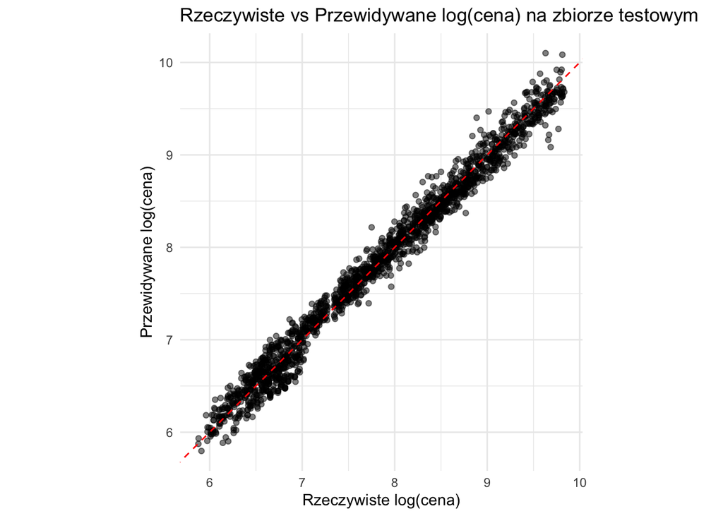

- Na wykresie widać, że model jest bardzo precyzyjny, (wartości przewidywane ją bardzo bliskie wartościom rzeczywistym). Dodatkowo, punkty są rozłożone równomiernie po obu stronach czerwonej linii. Nie widać, aby model systematycznie zawyżał (punkty pod linią) lub zaniżał (punkty nad linią) prognozy. Oprócz, tego, wykres potwierdza nam wartość R-kwadrat. Gdyby R-kwadrat był niski, punkty tworzyłyby luźną, rozproszoną „chmurę”. Tak ciasne skupienie wokół linii jest typowe dla R-kwadrat przekraczającego 98%.

## 3b. Wizualizacja danych i prezentacja wyników

Warto zwrócić uwagę na fakt, że zlogarytmowanie zmiennej ‘Price’, sprawia, że model jest o wiele bardziej dopasowany do założeń statystyczych. Po samym porównaniu dwóch wykresów możemy dojść do wniosku, że rozkład jest znacznie bardziej symetryczny oraz jej wariancja jest bardziej stabilna niż w przypadku modelu z niezlogarytmowaną zmienną ‘Price’:

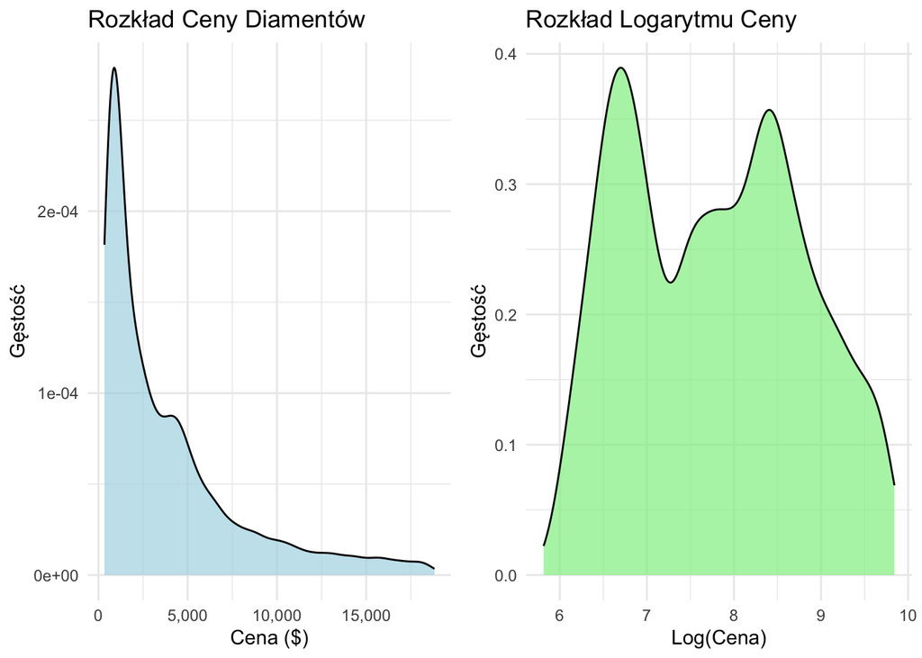

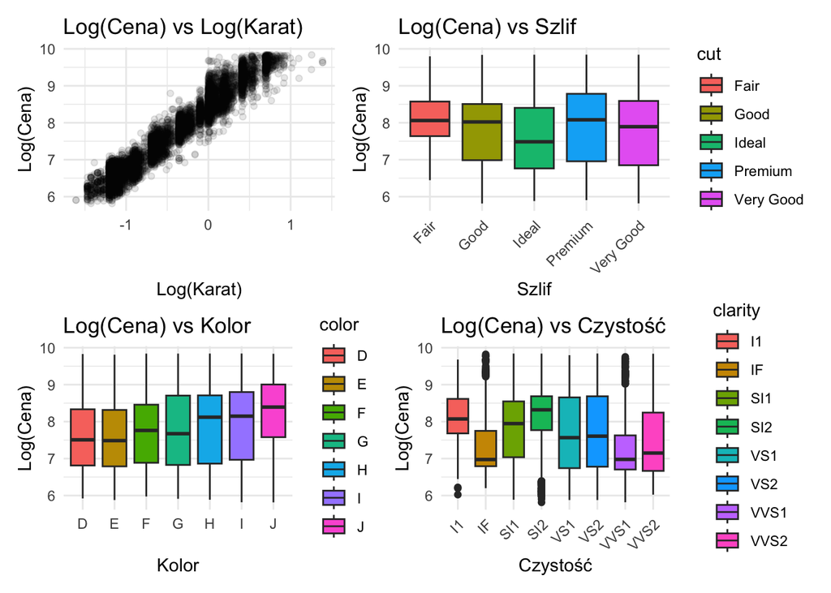

**Log(Price) vs Log(Carat)**

**Log(Price) vs Cut**

- Zależność jest bardziej złożona i nieoczywista. Wbrew intuicji, szlif “Ideal” (uważany za najlepszy) ma jedną z niższych median cen, niższą niż “Premium” czy “Very Good”. Najgorszy szlif (“Fair”) również ma relatywnie wysoką medianę ceny. Ten wykres jest klasycznym przykładem wpływu zmiennej zakłócającej (confounding variable).

**Log(Price) vs Color**

**Log(Price) vs Clarity**

## 3c. Weryfikacja założeń modelu i analiza reszt

- Po zbudowaniu modelu kluczowe jest sprawdzenie, czy jego założenia zostały spełnione. W tym celu przeanalizowano reszty (różnice między wartością rzeczywistą a przewidywaną) na zbiorze testowym.
- **Liniowość i Homoskedastyczność**

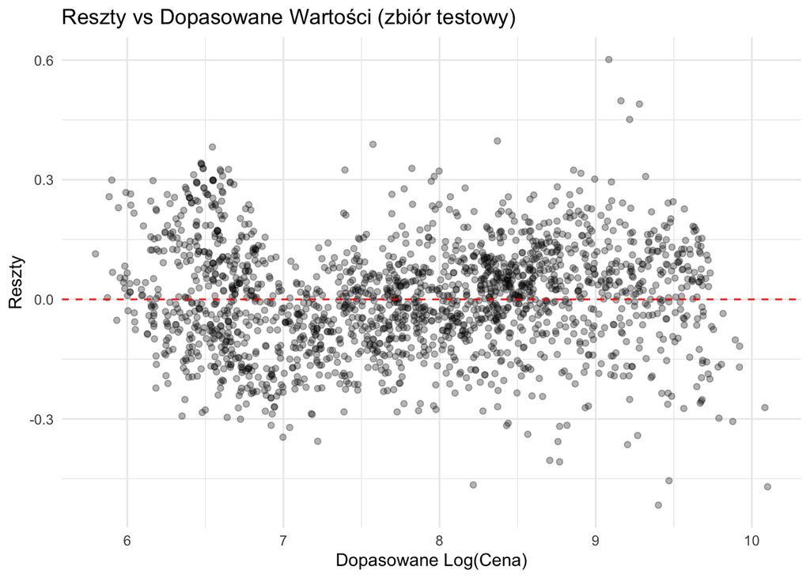

**Stała wariancja:** (Homoskedastyczność): Grubość chmury punktów jest stała na całej osi X, co oznacza brak problemu heteroskedastyczności modelu

**Braku systematycznego błędu:** Chmura punktów jest równomiernie rozłożona powyżej i poniżej linii y=0. Oznacza to, że model nie ma tendencji do zawyżania ani zaniżania cen. Wykres ten potwierdził, że zbudowany model dostarczył mocnych dowodów na to, że jest dobrze dopasowany i poprawnie generalizuje nowe dane.

- Normalność rozkładu reszt

Aby sprawdzić, czy błędy modelu rozkładają się losowo (zgodnie z rozkładem normalnym), stworzono histogram reszt oraz wykres kwantylowy.

- Histogram reszt

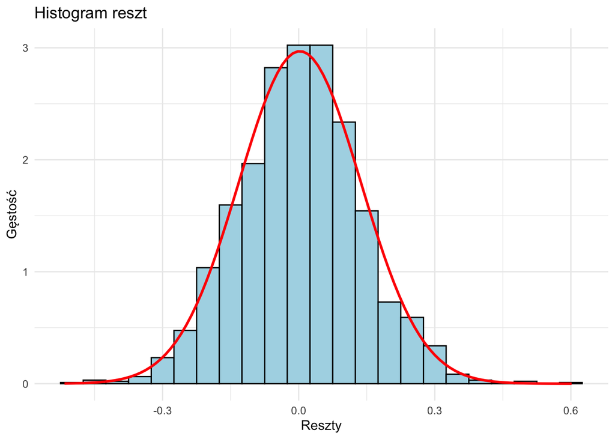

```r
p_hist_res
```

**Model jest poprawny metodologicznie, ponieważ jego błędy (reszty) przypominają rozkład normalny.**

- Wykres kwantylowy

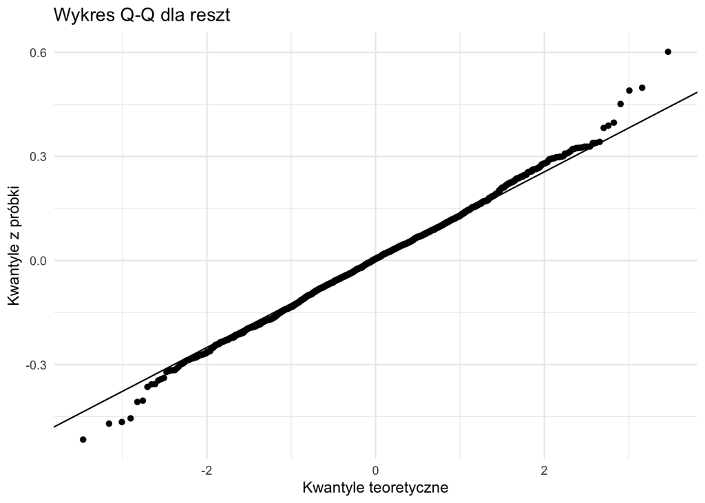

```r
p_qq_res
```

**Punkty leżą niemalże idealnie na prostej linii. Oznacza to, że błędy w modelu zachowują się tak, jak powinny (potwierdzenie o normalności błędów)**.

# 4. Wyniki i wnioski

**Na podstawie przeprowadzonej analizy danych i zbudowanego modelu można wysnuć następujące wnioski:**

**Zmienne o największym i najmniejszym wpływie na ceny diamentów**

- Analiza istotności współczynników modelu *(summary(model))* oraz wizualizacje (wykresy pudełkowe i rozrzutu) pozwoliły precyzyjnie określić, które cechy diamentu mają największy, a które najmniejszy wpływ na jego cenę.

**Zmienne o najmniejszym (nieistotnym) wpływie**

- Depth: Wartość p-value dla tej zmiennej wyniosła *0.343*. Jest to wartość znacznie powyżej progu *0.05*, co oznacza, że depth jest statystycznie nieistotna w tym modelu.
- Table: Podobnie jak depth, zmienna ta uzyskała wysokie p-value *(0.154)*, co również czyni ją statystycznie nieistotną.